# Unit 3: On Tools and Algorithms

## 3.4 Priority queues, heaps, and back to sorting

We can’t cover all of the fundamental algorithms and data structures in this course, so we chose one non-trivial data structure to focus on. This is the heap data structure. It will be used here for sorting, used in Unit 5 for algebraic manipulations, and used in Unit 6 as an aid for discrete event simulation.

Note: do not confuse the heap data structure with the other computer science usage of “heap”, also known as “free store” which refers to the place in [memory](https://en.wikipedia.org/wiki/Memory_management) where allocations happen. In Julia the heap is used for allocations of immutable types and has garbage collection. More on that in Unit 4.

Before starting to see what a heap does (we’ll continue in more depth in future units on how it works), we’ll discuss what we expect it to do - namely implement an efficient **priority queue**.

Consider for example a hypothetical situation where thousands of individuals attend a mass vaccination centre. As they arrive, each individual is tagged by their name (a `String`), and recieves a priority for vaccination which is a number (say `Float32`). Assume (hypothetically) that the priority is a function of their age, their occupation (essential or not), and their medical condition. Hence there are many possible different priorities.

Continuing with this example, assume the individuals queue (e.g. wait in a big arena or showgrounds area) and are only called when their priority is the highest (clearly high priority individuals won’t queue much while others wait for a long while). The management system will then keep track of the priorities of the individuals and do the following:

- Add individuals (this will happen at every arbitrary time in which someone arrives).
- Remove the individual with the highest priority (they then get vaccinated and leave).
- Modify an individual’s priority if they complain about waiting too long or in case of other reasons.

There are different alternatives for implementing such a data structure and in all cases the associated “collection” will be called a **priority queue**. It turns out that the heap data structure is the most efficient way to implement a priority (certainly if the number of items is large). But for starters lets consider some naive implemintations.

A small digression is to see the Julia type of **named tuples**; which present one way of keeping individuals:

```julia
person_A = (priority = 23.2, name = "Zack") #This is a named tuple,
person_B = (priority = 12.6, name = "Lenna")#if there wasn't "priority =" and "name =" it would just be a tuple

@show typeof(person_A)
@show person_A
@show person_B;

@show person_A.name
@show person_B.priority;
```

```
typeof(person_A) = @NamedTuple{priority::Float64, name::String}
person_A = (priority = 23.2, name = "Zack")
person_B = (priority = 12.6, name = "Lenna")
person_A.name = "Zack"
person_B.priority = 12.6
```

So the type of these objects is `NamedTuple{(:priority, :name), Tuple{Float64, String}}` and they are just convient to work with.

Now back to our naive priority queue. We will just keep an array of the named tuples (the naiveness is not because of the named tuples but because of the fact we are using an array).

```julia
#Create an empty priorty queue as an array of named tuples
naive_priority_queue = NamedTuple{(:priority, :name), Tuple{Float64, String}}[];
```

Now in the most naive implementation, every time we add an individual we’ll just `push!` their named tuple to the array. For example,

```julia
new_person = (priority = 123.2, name = "Yarden")
push!(naive_priority_queue,new_person)

another_new_person = (priority = 12.5, name = "Sharon")
push!(naive_priority_queue,another_new_person)

yet_another_new_person = (priority = 4.4, name = "Miriam")
push!(naive_priority_queue,yet_another_new_person)

even_another_new_person = (priority = 54.2, name = "Moshe")
push!(naive_priority_queue,even_another_new_person)


naive_priority_queue
```

```
4-element Vector{@NamedTuple{priority::Float64, name::String}}:
 (priority = 123.2, name = "Yarden")
 (priority = 12.5, name = "Sharon")
 (priority = 4.4, name = "Miriam")
 (priority = 54.2, name = "Moshe")
```

Note that (in principle) such a `push!` is a costly operation because from time to time new memory needs to be allocated and the whole array copied.

Then each time we wish to remove an individual there will be the the costly (why?) operation of `deleteat!`. This is $O(n)$ every time.

```julia
index_of_person_we_want_to_delte = 3 #Say we know this index
deleteat!(naive_priority_queue, index_of_person_we_want_to_delte)
naive_priority_queue
```

```
3-element Vector{@NamedTuple{priority::Float64, name::String}}:
 (priority = 123.2, name = "Yarden")
 (priority = 12.5, name = "Sharon")
 (priority = 54.2, name = "Moshe")
```

Finally searching for the individual with the highest priority is also $O(n)$.

```julia
# You can ignore the type annotations of the inputs and outputs for now
function get_next_person(priority_queue::Vector{NamedTuple{(:priority, :name), Tuple{Float64, String}}})::NamedTuple{(:priority, :name), Tuple{Float64, String}}
   @assert !isempty(priority_queue)
   max_p = first(priority_queue)
   for p in priority_queue
      (p.priority > max_p.priority) && (max_p = p)
   end
   return max_p
end

get_next_person(naive_priority_queue)
```

```
(priority = 123.2, name = "Yarden")
```

Now you may think of simple ways to improve this, for example by enforcing the **invariant** that `naive_priority_queue` is always sorted. But this then implies that adding individuals is an $O(n)$ worst case operation.

Now in a scenario like a mass vaccination centre it isn’t really a problem to use such a priority queue with $O(n)$ costs for most operations. This is because the frequency of events is not high and neither is $n$. However, in other scenarios where events (additions, deletions, finding the maximum priority) occur very frequently then $O(n)$ for each operation may be very painful. For example, what if you were simulating that vaccination centre on a computer (similar simulations will be considered in Unit 6).

## 3.5 The Heap data structure

The heap data structure is a smarter tree based way of keeping the elements of a priority queue. With this data structure, finding the maximum is $O(1)$, deleting the maximum is $O(\log n)$, insertions are $O(\log n)$, and updating of a priority is $O(\log n)$. We’ll see the way it is implemented in Unit 6, but for now we’ll use it as a “black box”.

One implementation we can use is from DataStructures.jl.

Now observe that since the operations of insertions and deletion of the maximum are efficient, we also get an efficient sorting algorithm:

**The heap sort algorithm** just pushes the values to be sorted into a heap and then pops out the maximal value one after the other. Since there are $n$ values and putting in a value takes $O(\log n)$ time, putting all $n$ values in requires $O(n \log n)$ time. Then popping the values another $O(n \log n)$ time so the total time is twice of that which is still $O(n \log n)$. This is much better than the $O(n^2)$ of bubble sort and is equivalent to the best (asymptotic) sorting performance possible.

```julia
using Random, DataStructures
Random.seed!(0)


function heap_sort!(a::AbstractArray)
   h = BinaryMinHeap{eltype(a)}()
   for e in a
      push!(h, e) #This is an O(log n) operation
   end

   #Write back onto the original array
   for i in 1:length(a)
      a[i] = pop!(h) #This is an O(log n) operation
   end
   return a
end

data = [65, 51, 32, 12, 23, 84, 68, 1]
heap_sort!(data)
data
```

```
8-element Vector{Int64}:
  1
 12
 23
 32
 51
 65
 68
 84
```

Lets carry out rough benchmarks. As we can see (even though this is a very sloppy timing mechanism), there appears to be linear growth. Note that the difference between $O(n)$ and $O(n \log n)$ is hard to pick up with sloppy timings such as this.

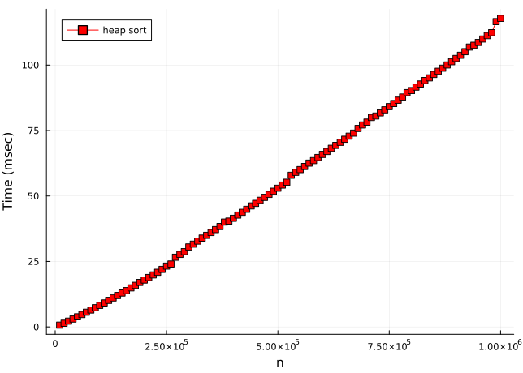

```julia
Random.seed!(0)

function do_timing()
   data = rand(Int64,10^8)

   n_range = 10^4:10^4:10^6
   times_heap_sort = Vector{Float64}(undef,0)


   for n in n_range
      GC.enable(false) #This turns off garbage collection
      start_time = time_ns()
      heap_sort!(data[1:n])
      end_time = time_ns()
      GC.enable(true) #GC back on
      push!(times_heap_sort, Int(end_time - start_time)/10^6) #time in milliseconds
   end
   return times_heap_sort, n_range
end

times_heap_sort, n_range = do_timing()

plot(n_range,times_heap_sort,
   shape = :square, c = :red, legend = :topleft,
   label="heap sort",xlabel = "n", ylabel = "Time (msec)")
```

Lets also consider a single timing of $10^6$ data points:

```julia
Random.seed!(0)
data = rand(Int64,10^6)
@time heap_sort!(data);
```

```
  0.113767 seconds (31 allocations: 28.299 MiB)
```

And compare it with the in-built sort:

```julia
Random.seed!(0)
data = rand(Int64,10^6)
@time sort!(data);
```

```
  0.021837 seconds (15 allocations: 7.638 MiB)
```

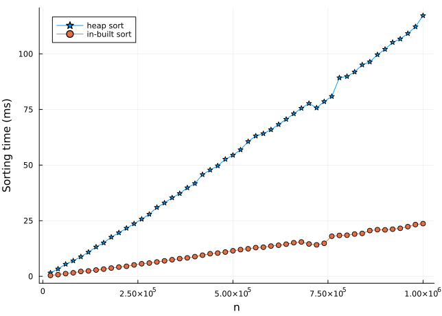

```julia
using Random, Plots
Random.seed!(0)

function do_timing()
   data = rand(Int64,10^6)

   n_range = 2*10^4:2*10^4:10^6
   times_heap_sort = Vector{Float64}(undef,0)
   times_in_built_sort = Vector{Float64}(undef,0)

   for n in n_range
      GC.enable(false)
      start_time = time_ns()
      heap_sort!(data[1:n])
      end_time = time_ns()
      GC.enable(true)
      push!(times_heap_sort, Int(end_time - start_time)/10^6) #time in milliseconds

      GC.enable(false)
      start_time = time_ns()
      sort!(data[1:n])
      end_time = time_ns()
      GC.enable(true)
      push!(times_in_built_sort, Int(end_time - start_time)/10^6) #time in milliseconds
   end
   return times_heap_sort, times_in_built_sort, n_range
end

times_heap_sort, times_in_built_sort, n_range = do_timing()

plot(n_range,times_heap_sort, label="heap sort",shape = :star)
plot!(n_range,times_in_built_sort, label = "in-built sort", shape = :circle,
   xlabel="n", ylabel="Sorting time (ms)", legend = :topleft)
```

So what is the in-built sort? Lets look at “quick sort”.

# 4 Quicksort (and Merge Sort on the way)

## 4.1 Merge Sort

On our path to understanding quick sort we’ll start with a different sorting algorithm Merge sort. It uses a [divide and conquer](https://en.wikipedia.org/wiki/Divide-and-conquer_algorithm) strategy somewhat similar to our target algorithm, quick-sort.

Here is an implementation of merge sort that is very wasteful in terms of memory copies (we won’t present a more efficient implementation here). Nevertheless the key principle is that when presented with sorting an array of length $n$, merge-sort splits it into two arrays of size $n/2$ (or close to that if $n$ is odd). Merge sort then sorts each of the sub-arrays by calling itself again (a recursive call), and then when presented with two sorted sub arrays merge sort merges them in order.

The code below implements this from first principles. It can be improved in terms of style and efficiency but is good enough to get the main idea:

```julia
#Note that there are much better implementations of this which avoid all this memory copying
function my_merge_sort(data)
   n = length(data)
   (n == 1) && return data
   p = n ÷ 2 #\div + [TAB]
   data_bottom = my_merge_sort(data[1:p]) #Get a sorted version of bottom half
   data_top = my_merge_sort(data[p+1:n]) #get a sorted version of top half
   data_new = Vector{eltype(data)}(undef,length(data))

   #Now merge, b and t are running indexes for the bottom and top
   b, t = 1, 1 #will
   for i in 1:n #loop on indexes of destination array
      if b > length(data_bottom) #if data_bottom array is finished
         data_new[i] = data_top[t]
         t += 1
         continue #returns to top of for loop
      end
      if t > length(data_top) #if data_top is finished
         data_new[i] = data_bottom[b]
         b += 1
         continue #returns to top of for loop
      end

      #if here then bottom and top are not finished - put the smaller element in the destination
      if data_bottom[b] <= data_top[t]
         data_new[i] = data_bottom[b]
         b += 1
      else
         data_new[i] = data_top[t]
         t+=1
      end
   end
   return data_new
end
```

```
my_merge_sort (generic function with 1 method)
```

```julia
Random.seed!(0)
data = rand(Int64,10^6)
@show my_merge_sort(data) == sort(data)

println("Time for Merge sort:")
@time my_merge_sort(data)

println("Time for in-built sort:")
@time sort(data);
```

```
my_merge_sort(data) == sort(data) = true
Time for Merge sort:
  0.193067 seconds (6.01 M allocations: 478.806 MiB, 23.08% gc time)
Time for in-built sort:
  0.022967 seconds (9 allocations: 15.267 MiB)
```

We will now analyze the computational complexity time of merge sort and see it is $O(n \log n$). The key is to consider the three main actions carried out by merge sort:

1. Sort the bottom sub list.
2. Sort the top sub list.
3. Merge the data.

If $T(n)$ is the time for sorting data of size $n$ then $T(n/2)$ is the time for sorting each sub-list. Further, you can see that the time to merge the two sub-lists is of order $O(n)$ because it requires running on the whole length of the dataset once. Hence we get,

$$T(n) = 2 T(\frac{n}{2}) + O(n).$$

This type of recursion is popular in several divide and conquer algorithms and we can now use the so called Master theorem for analysis of algorithms to see that this recursion is “solved by” $T(n) = O(n \log n)$. We won’t get into all the mathematical details, but as an illustration that this is sensible assume that the $O(n)$ term in the recursion is $C (\log 2)n$ (that is, assume a specific constant and ignore lower order $o(n)$ terms). Then by plugging in $T(n) = C n \log n$, for some constant $C$, we see it is a solution:

$$C n \log n = 2 C \frac{n}{2} \log \frac{n}{2} + C (\log 2) n = C n \log n.$$

The **Master theorem** allows to formalize this taking into considerations all possible $O(n)$ terms.

## 4.2 A quick glimpse at quick-sort

We now explore [quicksort](https://en.wikipedia.org/wiki/Quicksort). Like merge sort it is a divide and conquer algorithm. Implementing it is part of BigHW, so we won’t provide an implementation. However here is pseudocode adapted from Wikipedia broken up into two functions `quicksort` which operates on an array `A` indexed by `lo` and `hi` (in an initial call you would use `lo = 1` and `hi = length(A)`:

```
algorithm quicksort(A, lo, hi):
    if lo > 0 && hi > 0 then
         if lo < hi then
              p := partition(A, lo, hi)
              quicksort(A, lo, p - 1)
              quicksort(A, p + 1, hi)

algorithm partition(A, lo, hi):
    pivot := A[hi]
    i := lo - 1
    for j := lo to hi do
        if A[j] <= pivot then
            i := i + 1
            swap A[i] with A[j]
    return i
```

There are many resources on the web dealing with quicksort. Here is one very nice [recommended video](https://www.youtube.com/watch?v=0SkOjNaO1XY). Note that it uses Python where array indexing starts at `0` and not `1` like Julia. Also note that in Python `def` is how you define a function.

We note that quick-sort’s worst case complexity is actually $O(n^2)$ however on average it is $O(n \log n)$. Still, even though it doesn’t have guaranteed performance like merge sort or heap sort, it is a very fast algorithm and generally beats merge sort and heap sort in terms of the constants. It is also by default “in place”, just like it’s slow cousin, bubble sort.

Quicksort recently celebrated 60 years. Here is an useful [article](https://plus.maths.org/content/happy-birthday-quicksort) about it and here is the [follow-up](https://plus.maths.org/content/happy-birthday-quicksort-0) about it.